# Introducción al análisis de imágenes biomédicas con R

Fuentes de Datos Biomédicos y Web Semántica (#8235) · Grado en Ingeniería de la Salud

Dr. Antonio Canepa-Oneto

“5º Semestre / Curso 2026-2027”

# 1 Objetivos y planificación

Hasta ahora hemos trabajado con fuentes de datos **tabulares** (CSV, Excel), **semiestructuradas** (JSON, XML) y **semánticas** (RDF). En esta práctica damos el salto a una de las fuentes de datos más voluminosas de cualquier hospital: la **imagen médica**. Un único estudio de resonancia magnética puede ocupar cientos de megabytes, y el Servicio de Radiología es, con diferencia, el mayor productor de datos del sistema sanitario.

Al terminar la sesión deberíais ser capaces de:

1. Explicar qué es una imagen digital desde el punto de vista matemático y cómo se relaciona la rejilla de vóxeles con el espacio físico del paciente.
2. Distinguir los dos formatos de referencia, **DICOM** y **NIfTI**, y leerlos en R.
3. Extraer y anonimizar metadatos de una cabecera DICOM, convirtiéndolos en un `tibble`.
4. Visualizar cortes 2D y vistas ortogonales de un volumen 3D con `ggplot2`, incluyendo el *ventaneo* (*windowing*).
5. Ejecutar un *pipeline* mínimo de análisis: histograma de intensidades → normalización → segmentación → cuantificación de volúmenes → exportación.

| Bloque | Contenido | Tiempo orientativo |
| --- | --- | --- |
| 0 | Preparación y conceptos | 5 min |
| 1 | DICOM: lectura, metadatos y anonimización | 7 min |
| 2 | Visualización 2D y ventaneo | 5 min |
| 3 | NIfTI: volúmenes 3D y espacio físico | 5 min |
| 4 | Intensidades, normalización y segmentación | 6 min |
| 5 | Exportación del resultado | 2 min |

# 2 Preparación del entorno

Los paquetes que vamos a usar están recogidos en el **CRAN Task View: Medical Image Analysis** (https://cran.r-project.org/web/views/MedicalImaging.html), que es el índice curado de referencia para este ámbito en R. Usaremos tres de sus paquetes centrales:

- **`oro.dicom`**: lectura de ficheros DICOM y de sus cabeceras.
- **`oro.nifti`** / **`RNifti`**: lectura y escritura de NIfTI. `RNifti` es una interfaz en C muy rápida a la biblioteca de referencia `niftilib`; es la que usaremos para los volúmenes.
- **`tidyverse`** y **`patchwork`**: manipulación tidy y composición de figuras.

```r
# Ejecutad esto UNA sola vez (no forma parte del cuaderno renderizado)
install.packages(c("tidyverse", "oro.dicom", "oro.nifti", "RNifti", "patchwork"))
```

```r
library(tidyverse)
library(oro.dicom)
library(RNifti)
library(patchwork)
```

> **Nota del profesor.** Todos los datos de esta práctica vienen **dentro de los propios paquetes**, de modo que el cuaderno es 100 % reproducible sin conexión ni registro. En la sección 3 os explico por qué hemos hecho esto y cómo aplicar *exactamente el mismo código* a datos reales españoles.

# 3 Conceptos fundamentales

## 3.1 La imagen como función discreta

Formalmente, una imagen digital de dimensión $d$ es una función

$$I : \Omega \subset \mathbb{Z}^d \longrightarrow \mathbb{R}, \qquad (i,
j, k) \longmapsto I(i,j,k),$$

que asigna a cada elemento de una rejilla discreta (**píxel** si $d = 2$, **vóxel** si $d = 3$) un valor de **intensidad**. En R, esto no es más que un `array` numérico: una matriz para 2D, un array de tres índices para 3D y de cuatro para series temporales (fMRI, difusión, perfusión).

Pero la rejilla de índices no basta. Para que la imagen tenga sentido clínico necesitamos saber **dónde está cada vóxel en el cuerpo del paciente**, en milímetros. Esto se consigue con una **transformación afín** $A \in \mathbb{R}^{4\times 4}$ que lleva índices a coordenadas físicas:

$$\begin{pmatrix} x \\ y \\ z \\ 1 \end{pmatrix}
= A \begin{pmatrix} i \\ j \\ k \\ 1 \end{pmatrix},
\qquad
A = \begin{pmatrix} R \cdot \operatorname{diag}(\Delta_i, \Delta_j,
\Delta_k) & \mathbf{t} \\ \mathbf{0}^\top & 1 \end{pmatrix},$$

donde $\Delta$ es el tamaño del vóxel en mm, $R$ una matriz de rotación (o reflexión) que codifica la **orientación**, y $\mathbf{t}$ la posición del origen. Confundir esta orientación es uno de los errores clásicos del área: un hemisferio izquierdo que aparece a la derecha no es un problema estético, es un error clínico.

**Ejemplo mínimo.** Una “imagen” de $5 \times 5$ píxeles con un objeto brillante en el centro, tratada al estilo tidy (un píxel = una fila):

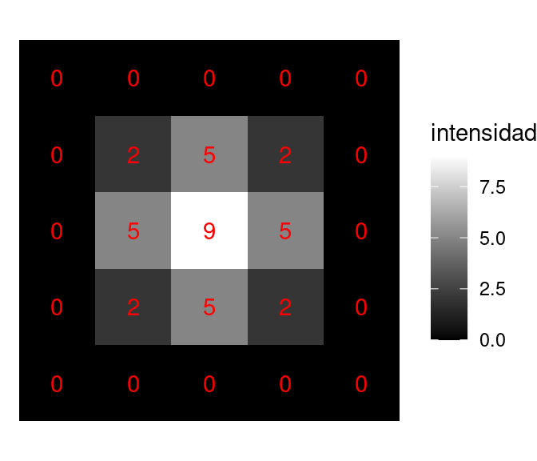

```r
juguete <- matrix(c(0, 0, 0, 0, 0,
                    0, 2, 5, 2, 0,
                    0, 5, 9, 5, 0,
                    0, 2, 5, 2, 0,
                    0, 0, 0, 0, 0), nrow = 5, byrow = TRUE)

# De matriz a tibble: una fila por píxel, con sus índices (i, j)
juguete_tbl <- expand_grid(i = 1:5, j = 1:5) |>
  mutate(intensidad = juguete[cbind(i, j)])

juguete_tbl |>
  ggplot(aes(x = j, y = i, fill = intensidad)) +
  geom_raster() +
  geom_text(aes(label = intensidad), colour = "red") +
  scale_y_reverse() +                     # fila 1 arriba, como en la matriz
  scale_fill_gradient(low = "black", high = "white") +
  coord_fixed() +
  theme_void()
```

Observad que ya hemos tenido que decidir **qué índice va en el eje horizontal y en qué sentido crece el vertical**. Esta decisión, trivial aquí, es exactamente la que codifican las cabeceras DICOM y NIfTI.

## 3.2 Formatos: DICOM frente a NIfTI

| Aspecto | **DICOM** (*Digital Imaging and Communications in Medicine*) | **NIfTI-1/2** (*Neuroimaging Informatics Technology Initiative*) |
| --- | --- | --- |
| Origen | Estándar clínico (NEMA, ISO 12052) | Comunidad de investigación (NIH, 2004) |
| Unidad típica | Un fichero por corte 2D | Un fichero por volumen 3D/4D |
| Metadatos | Cientos de etiquetas `(grupo, elemento)`: paciente, equipo, adquisición… | Cabecera fija de 348 bytes (NIfTI-1): dimensiones, vóxel, afín |
| Datos personales | **Sí** (nombre, ID, fecha de nacimiento…) | Normalmente no |
| Uso | PACS hospitalarios, intercambio clínico | Análisis cuantitativo, investigación |

El flujo habitual en investigación es: **PACS → DICOM → (anonimización) → conversión a NIfTI → análisis**. En R, la conversión puede hacerse con `oro.dicom::dicom2nifti()` o, de forma más robusta, con el paquete `divest`, que envuelve la herramienta de referencia `dcm2niix`.

## 3.3 Fuentes de imagen médica en España

España cuenta con algunos de los repositorios abiertos de imagen médica más relevantes de Europa:

- **BIMCV** (*Banco de Imágenes Médicas de la Comunidad Valenciana*, https://bimcv.cipf.es/), de la Conselleria de Sanitat y FISABIO/CIPF. Destaca **BIMCV-COVID19+**, con radiografías y TC de tórax de pacientes COVID-19 en formato estructurado BIDS.
- **PadChest**, distribuido a través de BIMCV y procedente del Hospital Universitario de San Juan de Alicante: más de 160 000 radiografías de tórax con informes etiquetados y mapeados a conceptos **UMLS**, lo que lo conecta directamente con la parte de Web Semántica de la asignatura.
- A escala europea, la infraestructura **EUCAIM** (*Cancer Image Europe*), en la que participan centros españoles, federa repositorios de imagen oncológica.

Todos ellos exigen **registro y la aceptación de un acuerdo de uso de datos**, como corresponde a datos de salud bajo el **RGPD** (art. 9, categorías especiales) y la LOPDGDD. Por eso, para la sesión de hoy usaremos ficheros de ejemplo incluidos en los paquetes de CRAN: un corte de RM abdominal en DICOM y un volumen cerebral de RM en NIfTI. Al final del cuaderno tenéis un bloque preparado para aplicar el mismo *pipeline* a PadChest o BIMCV una vez descargados.

# 4 Bloque 1: DICOM, lectura y metadatos

## 4.1 Lectura de un fichero

El paquete `oro.dicom` incluye un corte coronal de RM de abdomen ponderado en T2. `readDICOMFile()` devuelve una lista con dos elementos: `hdr` (la cabecera) e `img` (la matriz de píxeles).

```r
ruta_dcm <- system.file("dcm", "Abdo.dcm", package = "oro.dicom")
abdo <- readDICOMFile(ruta_dcm)

names(abdo)
```

```
## [1] "hdr" "img"
```

```r
dim(abdo$img)      # filas x columnas
```

```
## [1] 256 256
```

```r
range(abdo$img)    # rango de intensidades (unidades arbitrarias en RM)
```

```
## [1]    0 1168
```

## 4.2 La cabecera como tibble

La cabecera ya es un `data.frame`, así que la convertimos a `tibble` y la tratamos como cualquier otra fuente tabular del curso:

```r
cabecera <- as_tibble(abdo$hdr)
cabecera
```

```
## # A tibble: 84 × 7
##    group element name                       code  length value          sequence
##    <chr> <chr>   <chr>                      <chr> <chr>  <chr>          <chr>
##  1 0002  0000    GroupLength                UL    4      "166"          ""
##  2 0002  0001    FileMetaInformationVersion OB    2      "\u0001"       ""
##  3 0002  0002    MediaStorageSOPClassUID    UI    26     "1.2.840.1000… ""
##  4 0002  0003    MediaStorageSOPInstanceUID UI    38     "1.3.46.67058… ""
##  5 0002  0010    TransferSyntaxUID          UI    20     "1.2.840.1000… ""
##  6 0002  0012    ImplementationClassUID     UI    16     "1.3.46.67058… ""
##  7 0002  0013    ImplementationVersionName  SH    12     "ARC_CONVERT"  ""
##  8 0008  0005    SpecificCharacterSet       CS    10     "ISO_IR 100"   ""
##  9 0008  0008    ImageType                  CS    28     "ORIGINAL PRI… ""
## 10 0008  0012    InstanceCreationDate       DA    8      "19960823"     ""
## # ℹ 74 more rows
```

```r
etiquetas_clave <- c("Modality", "Manufacturer", "MagneticFieldStrength",
                     "SeriesDescription", "SliceThickness", "PixelSpacing",
                     "Rows", "Columns", "BitsStored",
                     "WindowCenter", "WindowWidth")

cabecera |>
  filter(name %in% etiquetas_clave) |>
  select(grupo = group, elemento = element, etiqueta = name, valor = value)
```

```
## # A tibble: 11 × 4
##    grupo elemento etiqueta              valor
##    <chr> <chr>    <chr>                 <chr>
##  1 0008  0060     Modality              MR
##  2 0008  0070     Manufacturer          Philips
##  3 0008  103E     SeriesDescription     Liver SpleeT2W UTSE RC$ COR    TSE   20…
##  4 0018  0050     SliceThickness        10.000000
##  5 0018  0087     MagneticFieldStrength 1.500000
##  6 0028  0010     Rows                  256
##  7 0028  0011     Columns               256
##  8 0028  0030     PixelSpacing          1.464844 1.464844
##  9 0028  0101     BitsStored            12
## 10 0028  1050     WindowCenter          530
## 11 0028  1051     WindowWidth           1052
```

Fijaos en la información que da contexto físico y técnico a los píxeles: equipo Philips de 1,5 T, cortes de 10 mm y píxeles de 1,465 mm. El **campo de visión** (FOV) es, por tanto:

```r
cabecera |>
  filter(name %in% c("Rows", "PixelSpacing")) |>
  select(name, value)
```

```
## # A tibble: 2 × 2
##   name         value
##   <chr>        <chr>
## 1 Rows         256
## 2 PixelSpacing 1.464844 1.464844
```

```r
pixel_mm <- extractHeader(abdo$hdr, "PixelSpacing", numeric = FALSE) |>
  str_split_1(" ") |>
  as.numeric()

fov_mm <- dim(abdo$img) * pixel_mm
fov_mm
```

```
## [1] 375.0001 375.0001
```

Unos 37,5 cm de lado: el abdomen completo de un adulto.

## 4.3 Anonimización

La cabecera contiene **información de identificación personal** (PHI). Antes de compartir cualquier imagen fuera del hospital, estas etiquetas deben eliminarse o sustituirse. Un ejemplo tidy, deliberadamente sencillo:

```r
etiquetas_phi <- c("PatientsName", "PatientID", "PatientsBirthDate",
                   "PatientsSex", "PatientsAge", "InstitutionName",
                   "ReferringPhysiciansName")

cabecera_anon <- cabecera |>
  mutate(value = if_else(name %in% etiquetas_phi, "ANONIMIZADO", value))

cabecera_anon |>
  filter(name %in% etiquetas_phi) |>
  select(name, value)
```

```
## # A tibble: 6 × 2
##   name                    value
##   <chr>                   <chr>
## 1 InstitutionName         ANONIMIZADO
## 2 ReferringPhysiciansName ANONIMIZADO
## 3 PatientsName            ANONIMIZADO
## 4 PatientID               ANONIMIZADO
## 5 PatientsBirthDate       ANONIMIZADO
## 6 PatientsSex             ANONIMIZADO
```

> **Nota del profesor.** Esto es una ilustración pedagógica, **no** una anonimización conforme a norma. El perfil de desidentificación de DICOM (PS3.15, Anexo E) enumera decenas de etiquetas, incluidos UIDs, fechas y etiquetas privadas del fabricante, y además pueden existir datos **incrustados en los propios píxeles** (texto sobreimpreso en ecografías o radiografías). En entornos reales se usan herramientas validadas.

# 5 Bloque 2: visualización 2D y ventaneo

## 5.1 Una función auxiliar tidy

Vamos a reutilizar la idea del ejemplo de juguete: convertir una matriz en un `tibble` largo, con una fila por píxel.

```r
matriz_a_tibble <- function(m) {
  expand_grid(i = seq_len(nrow(m)), j = seq_len(ncol(m))) |>
    mutate(intensidad = m[cbind(i, j)])
}

abdo_tbl <- matriz_a_tibble(abdo$img)
abdo_tbl
```

```
## # A tibble: 65,536 × 3
##        i     j intensidad
##    <int> <int>      <int>
##  1     1     1          0
##  2     1     2          0
##  3     1     3          0
##  4     1     4          0
##  5     1     5          0
##  6     1     6          0
##  7     1     7          0
##  8     1     8          0
##  9     1     9          0
## 10     1    10          0
## # ℹ 65,526 more rows
```

`oro.dicom` invierte las filas al leer (argumento `flipupdown = TRUE`), de forma que el índice de fila `i` crece hacia **craneal**. Situando las columnas `j` en el eje horizontal obtenemos la **convención radiológica**: el lado derecho del paciente aparece a la izquierda del observador.

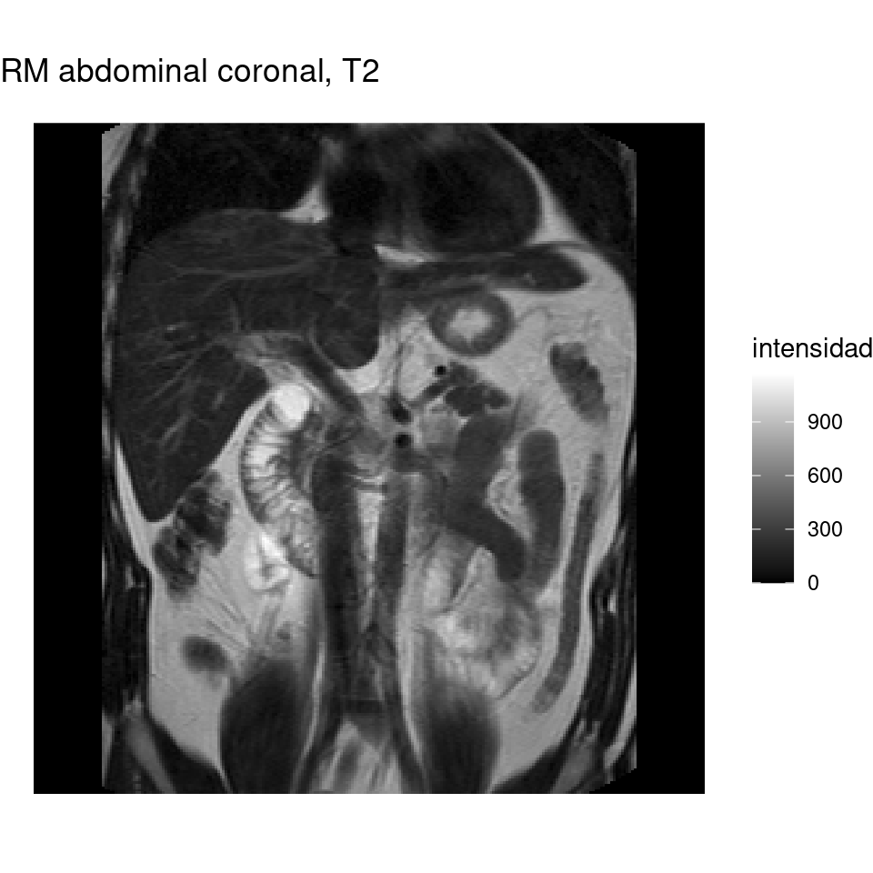

```r
tema_imagen <- theme_void() + theme(legend.position = "right")

abdo_tbl |>
  ggplot(aes(x = j, y = i, fill = intensidad)) +
  geom_raster() +
  scale_fill_gradient(low = "black", high = "white") +
  coord_fixed() +
  labs(title = "RM abdominal coronal, T2") +
  tema_imagen
```

Reconoced las estructuras: el hígado (hipointenso en T2) arriba a la izquierda del observador, las asas intestinales con contenido líquido muy brillantes y los cuerpos vertebrales en la línea media.

## 5.2 Ventaneo (*windowing*)

El ojo humano distingue unos pocos cientos de niveles de gris, pero el detector registra 12 bits (4096 niveles). El **ventaneo** aplica una transformación lineal a trozos que concentra el rango dinámico de la pantalla en el intervalo de interés, definido por un **centro** $C$ y una **anchura** $W$:

$$g(x) =
\begin{cases}
0 & x \le C - W/2 \\[2pt]
\dfrac{x - (C - W/2)}{W} & C - W/2 < x < C + W/2 \\[6pt]
1 & x \ge C + W/2
\end{cases}$$

En TC, donde las intensidades son **unidades Hounsfield** con significado físico (agua = 0 HU, aire = −1000 HU), las ventanas están estandarizadas: pulmón ($C = -600$, $W = 1500$), mediastino ($C = 40$, $W = 400$), hueso ($C = 400$, $W = 1800$). En RM las unidades son arbitrarias, y por eso el equipo propone una ventana en la propia cabecera.

```r
ventana <- function(x, centro, anchura) {
  pmin(pmax((x - (centro - anchura / 2)) / anchura, 0), 1)
}

wc <- extractHeader(abdo$hdr, "WindowCenter")
ww <- extractHeader(abdo$hdr, "WindowWidth")
c(centro = wc, anchura = ww)
```

```
##  centro anchura
##     530    1052
```

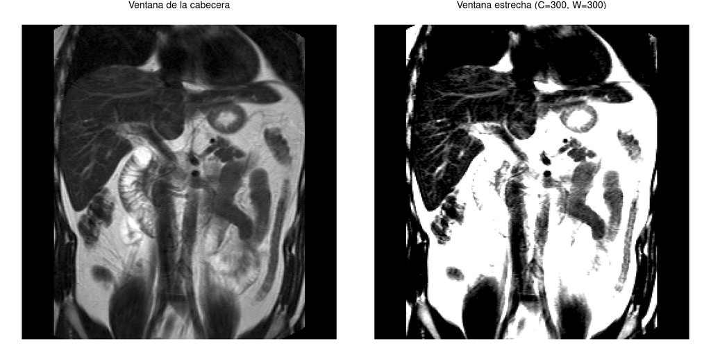

```r
abdo_ventanas <- abdo_tbl |>
  mutate(
    `Ventana de la cabecera`     = ventana(intensidad, wc, ww),
    `Ventana estrecha (C=300, W=300)` = ventana(intensidad, 300, 300)
  ) |>
  select(-intensidad) |>
  pivot_longer(-c(i, j), names_to = "ventana", values_to = "gris")

abdo_ventanas |>
  ggplot(aes(j, i, fill = gris)) +
  geom_raster() +
  scale_fill_gradient(low = "black", high = "white", guide = "none") +
  coord_fixed() +
  facet_wrap(~ ventana) +
  theme_void()
```

Con la ventana estrecha centrada en tonos bajos ganamos contraste dentro del hígado y el bazo a costa de saturar en blanco todo el contenido líquido. **El ventaneo no modifica los datos, solo su representación**: es un parámetro de visualización, no de análisis.

# 6 Bloque 3: NIfTI y volúmenes 3D

## 6.1 Lectura y cabecera

Ahora trabajamos con un volumen cerebral de RM ponderado en T2, de baja resolución, en el que el líquido cefalorraquídeo (LCR) aparece hiperintenso y del que ya se ha extraído el cerebro (*skull stripping*: todo lo que no es intracraneal vale 0). Viene incluido en `RNifti`:

```r
ruta_nii <- system.file("extdata", "example.nii.gz", package = "RNifti")
cerebro <- readNifti(ruta_nii)

cerebro
```

```
## Image array of mode "integer" (2.1 Mb)
## - 96 x 96 x 60 voxels
## - 2.5 x 2.5 x 2.5 mm per voxel
```

```r
dim(cerebro)          # vóxeles en i, j, k
```

```
## [1] 96 96 60
```

```r
pixdim(cerebro)       # tamaño del vóxel en mm
```

```
## [1] 2.5 2.5 2.5
```

```r
orientation(cerebro)  # código de orientación
```

```
## [1] "LAS"
```

```r
xform(cerebro)        # matriz afín A (índices -> mm)
```

```
##      [,1] [,2] [,3]      [,4]
## [1,] -2.5  0.0  0.0 122.03390
## [2,]  0.0  2.5  0.0 -95.18523
## [3,]  0.0  0.0  2.5 -55.03814
## [4,]  0.0  0.0  0.0   1.00000
## attr(,"imagedim")
## [1] 96 96 60
## attr(,"code")
## [1] 2
```

Interpretemos la salida:

- 96 × 96 × 60 vóxeles **isotrópicos** de 2,5 mm, es decir, un volumen de vóxel de $2{,}5^3 = 15{,}625\ \text{mm}^3$.
- La orientación `LAS` significa que el índice $i$ crece hacia la izquierda (*Left*) del paciente, $j$ hacia anterior y $k$ hacia superior. El $-2{,}5$ de la diagonal de la matriz afín es precisamente esa reflexión en el eje $x$ del espacio físico, que en NIfTI sigue el convenio RAS+.

Podemos comprobar la fórmula de la sección 3.1 calculando la posición física del vóxel central. Atención: NIfTI indexa desde 0, R desde 1.

```r
vox_centro <- c(48, 48, 30)
xform(cerebro) %*% c(vox_centro - 1, 1)
```

```
##           [,1]
## [1,]  4.533897
## [2,] 22.314766
## [3,] 17.461864
## [4,]  1.000000
```

## 6.2 Vistas ortogonales en formato tidy

Extraemos los tres cortes centrales (axial, coronal y sagital) y los apilamos en un único `tibble` largo con una columna `plano`, lo que nos permite usar `facet_wrap()`:

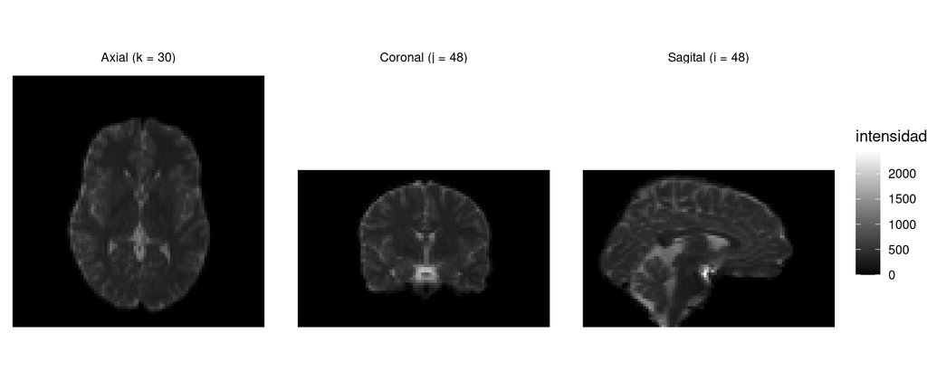

```r
corte_tbl <- function(m, plano) {
  matriz_a_tibble(m) |> mutate(plano = plano)
}

ortogonales <- bind_rows(
  corte_tbl(cerebro[, , 30], "Axial (k = 30)"),
  corte_tbl(cerebro[, 48, ], "Coronal (j = 48)"),
  corte_tbl(cerebro[48, , ], "Sagital (i = 48)")
) |>
  mutate(plano = fct_inorder(plano))

ortogonales |>
  ggplot(aes(x = i, y = j, fill = intensidad)) +
  geom_raster() +
  scale_fill_gradient(low = "black", high = "white") +
  coord_fixed() +
  facet_wrap(~ plano) +
  tema_imagen
```

Como los vóxeles son isotrópicos, `coord_fixed()` con razón 1 basta. Si no lo fueran (por ejemplo, cortes de 10 mm como en la RM abdominal), la razón de aspecto debería ser $\Delta_y / \Delta_x$.

# 7 Bloque 4: intensidades, normalización y segmentación

## 7.1 Del volumen a un tibble de vóxeles

El análisis cuantitativo trabaja sobre los vóxeles **del tejido**, no sobre el fondo. Como el cerebro ya está extraído, la máscara cerebral es simplemente `cerebro > 0`. Construimos un `tibble` con un vóxel por fila, conservando su índice lineal para poder reconstruir el volumen al final:

```r
voxeles <- tibble(
  idx        = which(cerebro > 0),
  intensidad = as.numeric(cerebro[idx])
)

voxeles
```

```
## # A tibble: 114,555 × 2
##      idx intensidad
##    <int>      <dbl>
##  1  2734        351
##  2  2735         79
##  3  2736         90
##  4  2737        141
##  5  2738         68
##  6  2739        197
##  7  2740        125
##  8  2829        268
##  9  2830        335
## 10  2831        594
## # ℹ 114,545 more rows
```

```r
# Volumen de la máscara en mL (1 mL = 1000 mm^3)
vol_voxel_mm3 <- prod(pixdim(cerebro))
nrow(voxeles) * vol_voxel_mm3 / 1000
```

```
## [1] 1789.922
```

## 7.2 Histograma y normalización

El histograma es la herramienta diagnóstica básica de cualquier *pipeline* de imagen:

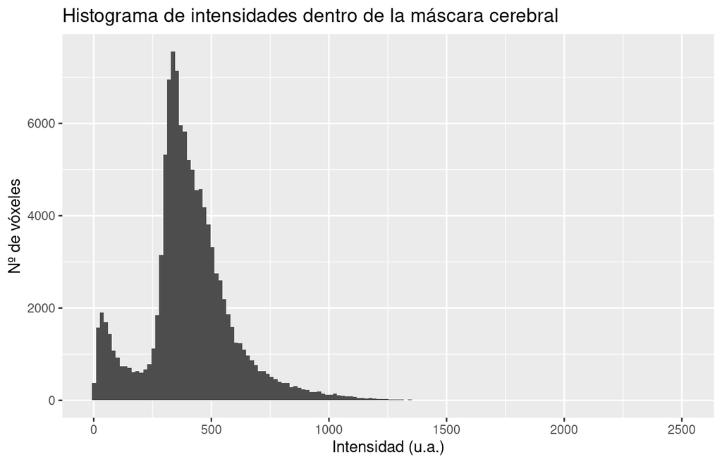

```r
voxeles |>
  ggplot(aes(intensidad)) +
  geom_histogram(bins = 150, fill = "grey30") +
  labs(x = "Intensidad (u.a.)", y = "Nº de vóxeles",
       title = "Histograma de intensidades dentro de la máscara cerebral")
```

La distribución es asimétrica, con una moda de tejido (sustancias blanca y gris, solapadas) y una cola larga de intensidades altas que corresponde al LCR. Como en RM **las intensidades no tienen unidades absolutas** (dependen del equipo, la bobina, la ganancia del receptor…), es imprescindible **normalizar** antes de comparar sujetos. La normalización más sencilla es el *z-score* dentro de la máscara:

$$z(\mathbf{v}) = \frac{I(\mathbf{v}) -
\mu_{\text{máscara}}}{\sigma_{\text{máscara}}}$$

```r
voxeles <- voxeles |>
  mutate(z = (intensidad - mean(intensidad)) / sd(intensidad))

voxeles |>
  summarise(media = mean(z), dt = sd(z),
            p01 = quantile(z, 0.01), p99 = quantile(z, 0.99))
```

```
## # A tibble: 1 × 4
##      media    dt   p01   p99
##      <dbl> <dbl> <dbl> <dbl>
## 1 7.33e-17     1 -2.05  3.19
```

Existen métodos más robustos (normalización por percentiles, *WhiteStripe*, igualación de histogramas), y en la práctica real se corrige antes la **inhomogeneidad de campo** (*bias field*, por ejemplo con N4) para que un mismo tejido tenga la misma intensidad en todo el volumen.

## 7.3 Segmentación por *k-means*

**Segmentar** es asignar a cada vóxel una etiqueta de tejido. El método más simple basado en intensidad es *k-means* con $k = 3$ clases, que minimiza la varianza intraclase:

$$\min_{\{C_c\}} \sum_{c=1}^{3} \sum_{\mathbf{v} \in C_c}
\bigl(z(\mathbf{v}) - \mu_c\bigr)^2 .$$

Como *k-means* devuelve etiquetas arbitrarias (1, 2, 3), las ordenamos por su centroide. En T2 el orden esperado sería LCR > sustancia gris > sustancia blanca, pero aquí seremos prudentes y hablaremos de **clases de intensidad**; enseguida veremos por qué:

```r
set.seed(8235)
km <- kmeans(voxeles$z, centers = 3, nstart = 10)

# Ordenamos los centroides para dar nombre anatómico a cada clase
etiquetas <- tibble(cluster = 1:3, centro = as.numeric(km$centers)) |>
  arrange(centro) |>
  mutate(tejido = factor(c("Hipointensa", "Intermedia", "Hiperintensa (LCR)"),
                         levels = c("Hipointensa", "Intermedia", "Hiperintensa (LCR)")),
         etiqueta = as.integer(tejido))
etiquetas
```

```
## # A tibble: 3 × 4
##   cluster  centro tejido             etiqueta
##     <int>   <dbl> <fct>                 <int>
## 1       2 -1.62   Hipointensa               1
## 2       1 -0.0715 Intermedia                2
## 3       3  1.62   Hiperintensa (LCR)        3
```

```r
voxeles <- voxeles |>
  mutate(cluster = km$cluster) |>
  left_join(etiquetas, by = "cluster")
```

## 7.4 Cuantificación de volúmenes

Pasar de vóxeles a **mililitros** es una operación tidy elemental, y es el tipo de biomarcador de imagen que luego acaba en una tabla clínica:

```r
volumenes <- voxeles |>
  count(tejido, name = "n_voxeles") |>
  mutate(volumen_mL = n_voxeles * vol_voxel_mm3 / 1000,
         fraccion   = volumen_mL / sum(volumen_mL))
volumenes
```

```
## # A tibble: 3 × 4
##   tejido             n_voxeles volumen_mL fraccion
##   <fct>                  <int>      <dbl>    <dbl>
## 1 Hipointensa            14557       227.    0.127
## 2 Intermedia             81866      1279.    0.715
## 3 Hiperintensa (LCR)     18132       283.    0.158
```

La clase hiperintensa (unos 280 mL, en torno al 16 %) es compatible con el LCR intracraneal (ventrículos y surcos) más los vóxeles de borde con volumen parcial. Las otras dos, en cambio, **no se corresponden con sustancia blanca y gris**: una relación SB/SG de 1 a 5 es anatómicamente imposible (en un adulto ambas son del mismo orden). Lo que *k-means* ha separado es la cola inferior del histograma del grueso del parénquima, y la figura siguiente revela qué es esa cola: **el anillo de vóxeles del borde de la máscara**, mezcla de tejido y fondo por volumen parcial. Retened esta lección: **un algoritmo siempre devuelve una partición; que esa partición tenga significado anatómico es algo que debéis verificar vosotros.**

## 7.5 Comprobación visual

Una segmentación nunca se da por buena sin inspeccionarla. Reconstruimos el volumen de etiquetas en un array y lo superponemos al corte axial:

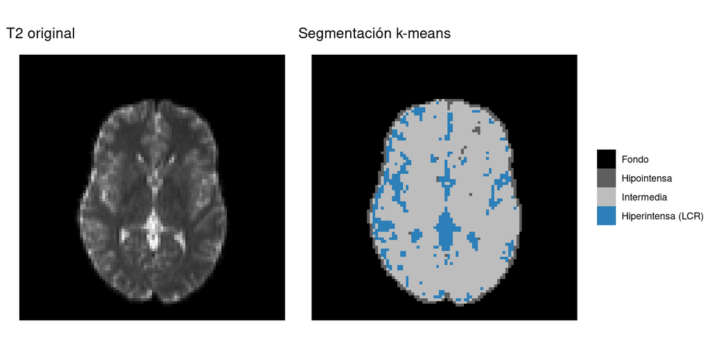

```r
seg <- array(0L, dim = dim(cerebro))
seg[voxeles$idx] <- voxeles$etiqueta

k <- 30
p_orig <- matriz_a_tibble(cerebro[, , k]) |>
  ggplot(aes(i, j, fill = intensidad)) +
  geom_raster() +
  scale_fill_gradient(low = "black", high = "white", guide = "none") +
  coord_fixed() + theme_void() + labs(title = "T2 original")

p_seg <- matriz_a_tibble(seg[, , k]) |>
  mutate(tejido = factor(intensidad, levels = 0:3,
                         labels = c("Fondo", levels(etiquetas$tejido)))) |>
  ggplot(aes(i, j, fill = tejido)) +
  geom_raster() +
  scale_fill_manual(values = c("black", "#5E5E5E", "#BDBDBD", "#2C7FB8")) +
  coord_fixed() + theme_void() + labs(title = "Segmentación k-means", fill = NULL)

p_orig + p_seg
```

> **Nota del profesor: limitaciones que debéis saber explicar.** (1) *k-means* solo usa la intensidad e ignora la vecindad espacial; los campos aleatorios de Markov (paquete `mritc` del Task View) incorporan esa información. (2) Supone implícitamente clases de varianza similar; los modelos de mezcla gaussiana relajan ese supuesto. (3) **Efecto de volumen parcial**: con vóxeles de 2,5 mm muchos contienen mezcla de tejidos, y el borde de ventrículos y surcos cae en clases intermedias. (4) El contraste entre sustancia gris y blanca en esta imagen T2 de baja resolución es pobre; por eso la segmentación tisular en neuroimagen se hace sobre T1 de alta resolución (≈ 1 mm) y con mapas de probabilidad *a priori* de un atlas (FSL FAST, SPM, ANTs Atropos). (5) Sin una segmentación manual de referencia no podemos calcular métricas de validación como el coeficiente de Dice, $\mathrm{DSC} = 2|A \cap B| / (|A| + |B|)$.

# 8 Bloque 5: exportación del resultado

El resultado de un análisis de imagen es, a su vez, **una imagen**, y debe guardarse con la misma geometría (afín, orientación, tamaño de vóxel) que la original para que cualquier visor (ITK-SNAP, 3D Slicer, FSLeyes) la superponga correctamente. `asNifti()` con `reference` copia la cabecera espacial:

```r
seg_nii <- asNifti(seg, reference = cerebro)
ruta_salida <- file.path(tempdir(), "segmentacion_kmeans.nii.gz")
writeNifti(seg_nii, ruta_salida)

# Comprobación: misma geometría que la imagen original
seg_releida <- readNifti(ruta_salida)
all.equal(xform(seg_releida), xform(cerebro))
```

```
## [1] TRUE
```

```r
table(seg_releida)
```

```
## seg_releida
##      0      1      2      3
## 438405  14557  81866  18132
```

Y, en coherencia con el resto del curso, la tabla de volúmenes se exporta como cualquier otra fuente tabular:

```r
write_csv(volumenes, "volumenes_tejido.csv")
```

# 9 Aplicación a datos reales españoles (para casa)

Una vez registrados en BIMCV y descargada una imagen de **PadChest** (radiografías de tórax en PNG de 16 bits), el *pipeline* de los bloques 2 y 4 se aplica casi sin cambios. Este bloque no se ejecuta al renderizar:

```r
# install.packages("png")
library(png)

rx <- readPNG("ruta/a/vuestra/imagen_padchest.png")   # matriz con valores en [0, 1]
rx <- rx[nrow(rx):1, ]                                 # fila 1 abajo, como en el bloque 2

matriz_a_tibble(rx) |>
  ggplot(aes(j, i, fill = intensidad)) +
  geom_raster() +
  scale_fill_gradient(low = "black", high = "white") +
  coord_fixed() +
  theme_void()

# Las etiquetas de PadChest vienen en un CSV con códigos UMLS:
# read_csv() + filter() sobre ese fichero os conecta con la práctica de RDF/SPARQL.
```

Para un estudio de **BIMCV-COVID19+** en NIfTI, basta con sustituir `ruta_nii` del bloque 3 por la ruta al fichero descargado.

# 10 Ejercicios propuestos

1. **Ventaneo.** Sobre la RM abdominal, busca un par $(C, W)$ que maximice el contraste entre hígado y bazo. Represéntalo junto a la ventana de la cabecera con `facet_wrap()`.
2. **Robustez de la segmentación.** Repite la segmentación con `k = 2` y `k = 4`, y con la intensidad bruta en lugar del *z-score*. ¿Cómo cambia el volumen de la clase hiperintensa? ¿Por qué el *z-score* no altera la partición de *k-means* en una sola variable, pero sí sería relevante al comparar sujetos? Como alternativa, implementa el **umbral de Otsu** (maximización de la varianza entre clases) con `map_dbl()` sobre una rejilla de umbrales candidatos y compáralo con `k = 2`.
3. **Volumen por corte.** Usando `arrayInd(voxeles$idx, dim(cerebro))`, añade la coordenada `k` a cada vóxel y representa con `geom_line()` el volumen de LCR por corte axial a lo largo del eje craneocaudal. Identifica en la curva el nivel de los ventrículos laterales.
4. **Metadatos semánticos.** Elige cinco etiquetas de la cabecera DICOM y propón cómo representarlas como tripletas RDF (sujeto: el estudio; predicado: la etiqueta DICOM). Pista: DICOM tiene su propia ontología, publicada en el NCBO BioPortal.

# 11 Para saber más

**Paquetes del CRAN Task View: Medical Image Analysis** que conviene conocer:

| Paquete | Para qué sirve |
| --- | --- |
| `oro.dicom`, `oro.nifti`, `RNifti` | Lectura/escritura de DICOM, ANALYZE y NIfTI |
| `divest` | Conversión DICOM → NIfTI con el motor de `dcm2niix` |
| `neurobase` | Funciones de alto nivel sobre objetos NIfTI (máscaras, visualización) |
| `fslr` | Interfaz a FSL desde R (requiere FSL instalado) |
| `mritc` | Clasificación de tejidos en RM con modelos espaciales (MRF) |
| `dcemriS4` | Análisis cuantitativo de RM con contraste dinámico (perfusión) |
| `imager` | Procesado general de imagen 2D/3D (filtros, morfología) |

Fuera de CRAN, el ecosistema **Neuroconductor** (`ANTsR`, `extrantsr`) ofrece registro y segmentación de nivel investigador, y en Bioconductor, **EBImage** está orientado a microscopía.

**Referencias**

- Whitcher, B., Schmid, V. J., y Thornton, A. (2011). Working with the DICOM and NIfTI data standards in R. *Journal of Statistical Software*, 44(6), 1–28.
- Muschelli, J., Gherman, A., Fortin, J.-P., et al. (2019). Neuroconductor: an R platform for medical imaging analysis. *Biostatistics*, 20(2), 218–239.
- Bustos, A., Pertusa, A., Salinas, J.-M., y de la Iglesia-Vayá, M. (2020). PadChest: a large chest X-ray image dataset with multi-label annotated reports. *Medical Image Analysis*, 66, 101797.
- de la Iglesia Vayá, M., Saborit, J. M., Montell, J. A., et al. (2020). BIMCV COVID-19+: a large annotated dataset of RX and CT images from COVID-19 patients. *arXiv:2006.01174*.
- NEMA. *DICOM PS3.15: Security and System Management Profiles*, Anexo E (perfiles de desidentificación).